**Vishv Patel**

**Student Number** : 8977662

# Practical Lab 3 - Univariate Linear Regression

In this lab, we have to train our first machine learning model - a univariate linear regression model using **California Housing Prices Dataset**. Each model will predict the median house value (dependent variable) based on one of the following independent variables:

1. Median income
2. Population
3. Number of households

For each model, I will analyze the relationship between the respective independent variable and the median house value to understand how each factor influences housing prices.

### Q1. Framing the Problem - Describe the goal of this report

The goal is to provide hands-on experience in building and interpreting a simple linear regression model, fostering a foundational understanding of machine learning concepts and techniques. Specifically, this involves analyzing the relationship between the median house value and each of the provided factors (independent variables) using linear regression.

This tool could prove invaluable for individuals looking to purchase a home in California regions.

### Q2. Getting the Data

##### This [link](https://www.kaggle.com/datasets/camnugent/california-housing-prices) leads to a dataset titled **'California Housing Prices'** on Kaggle. This dataset contains information regarding housing prices in various districts of California.

```python
import pandas as pd

# read the csv file
housing = pd.read_csv("data/housing.csv")
```

### Q3. Exploratory Data Analysis (EDA)

##### i. Explore statistics (e.g. using Pandas 'describe' function)

##### ii. Describe the 4 variables used in this lab. Review the range of the data for each variable, and other issues you notice.

```python
housing.describe() # To describe the data
```

|  | longitude | latitude | housing_median_age | total_rooms | total_bedrooms | population | households | median_income | median_house_value |
| --- | --- | --- | --- | --- | --- | --- | --- | --- | --- |
| count | 20640.000000 | 20640.000000 | 20640.000000 | 20640.000000 | 20433.000000 | 20640.000000 | 20640.000000 | 20640.000000 | 20640.000000 |
| mean | -119.569704 | 35.631861 | 28.639486 | 2635.763081 | 537.870553 | 1425.476744 | 499.539680 | 3.870671 | 206855.816909 |
| std | 2.003532 | 2.135952 | 12.585558 | 2181.615252 | 421.385070 | 1132.462122 | 382.329753 | 1.899822 | 115395.615874 |
| min | -124.350000 | 32.540000 | 1.000000 | 2.000000 | 1.000000 | 3.000000 | 1.000000 | 0.499900 | 14999.000000 |
| 25% | -121.800000 | 33.930000 | 18.000000 | 1447.750000 | 296.000000 | 787.000000 | 280.000000 | 2.563400 | 119600.000000 |
| 50% | -118.490000 | 34.260000 | 29.000000 | 2127.000000 | 435.000000 | 1166.000000 | 409.000000 | 3.534800 | 179700.000000 |
| 75% | -118.010000 | 37.710000 | 37.000000 | 3148.000000 | 647.000000 | 1725.000000 | 605.000000 | 4.743250 | 264725.000000 |
| max | -114.310000 | 41.950000 | 52.000000 | 39320.000000 | 6445.000000 | 35682.000000 | 6082.000000 | 15.000100 | 500001.000000 |

```python
housing.head() # To display the first few rows of a Dataset
```

|  | longitude | latitude | housing_median_age | total_rooms | total_bedrooms | population | households | median_income | median_house_value | ocean_proximity |
| --- | --- | --- | --- | --- | --- | --- | --- | --- | --- | --- |
| 0 | -122.23 | 37.88 | 41.0 | 880.0 | 129.0 | 322.0 | 126.0 | 8.3252 | 452600.0 | NEAR BAY |
| 1 | -122.22 | 37.86 | 21.0 | 7099.0 | 1106.0 | 2401.0 | 1138.0 | 8.3014 | 358500.0 | NEAR BAY |
| 2 | -122.24 | 37.85 | 52.0 | 1467.0 | 190.0 | 496.0 | 177.0 | 7.2574 | 352100.0 | NEAR BAY |
| 3 | -122.25 | 37.85 | 52.0 | 1274.0 | 235.0 | 558.0 | 219.0 | 5.6431 | 341300.0 | NEAR BAY |
| 4 | -122.25 | 37.85 | 52.0 | 1627.0 | 280.0 | 565.0 | 259.0 | 3.8462 | 342200.0 | NEAR BAY |

```python
housing.info() #  To displays various information about dataset
```

```
<class 'pandas.core.frame.DataFrame'>
RangeIndex: 20640 entries, 0 to 20639
Data columns (total 10 columns):
 #   Column              Non-Null Count  Dtype
---  ------              --------------  -----
 0   longitude           20640 non-null  float64
 1   latitude            20640 non-null  float64
 2   housing_median_age  20640 non-null  float64
 3   total_rooms         20640 non-null  float64
 4   total_bedrooms      20433 non-null  float64
 5   population          20640 non-null  float64
 6   households          20640 non-null  float64
 7   median_income       20640 non-null  float64
 8   median_house_value  20640 non-null  float64
 9   ocean_proximity     20640 non-null  object
dtypes: float64(9), object(1)
memory usage: 1.6+ MB
```

```python
housing.isnull().sum() # finding any null values in data
```

```
longitude               0
latitude                0
housing_median_age      0
total_rooms             0
total_bedrooms        207
population              0
households              0
median_income           0
median_house_value      0
ocean_proximity         0
dtype: int64
```

```python
# Describe each variable
print("Median House Value \n", housing['median_house_value'].describe(), "\n")
print("Median Income \n", housing['median_income'].describe(), "\n")
print("Population \n", housing['population'].describe(), "\n")
print("Households \n", housing['households'].describe(), "\n")
```

```
Median House Value
 count     20640.000000
mean     206855.816909
std      115395.615874
min       14999.000000
25%      119600.000000
50%      179700.000000
75%      264725.000000
max      500001.000000
Name: median_house_value, dtype: float64

Median Income
 count    20640.000000
mean         3.870671
std          1.899822
min          0.499900
25%          2.563400
50%          3.534800
75%          4.743250
max         15.000100
Name: median_income, dtype: float64

Population
 count    20640.000000
mean      1425.476744
std       1132.462122
min          3.000000
25%        787.000000
50%       1166.000000
75%       1725.000000
max      35682.000000
Name: population, dtype: float64

Households
 count    20640.000000
mean       499.539680
std        382.329753
min          1.000000
25%        280.000000
50%        409.000000
75%        605.000000
max       6082.000000
Name: households, dtype: float64
```

**Range of data for each variable is the values between minimum and maximum value**

1. Median House Value Range is : (14999.0, 500001.0)
2. Median Income Range is : (0.49, 15.0)
3. Population Range is : (3.0,35682.0)
4. Number of Households Range is : (1.0,6082.0)

##### **Key insights extracted from the dataset**

1. There are in total of 20640 examples in our Dataset
2. The dataset covers housing data for various locations in California, with longitude ranging from -124.35 to -114.31 and latitude ranging from 32.54 to 41.95.
3. The total_bedrooms column has missing values, as indicated by the count of 20,433 compared to the total count of 20,640 entries in the dataset.
4. The median income of the population ranges from 0.4999 to 15.0001, with a mean income of approximately 3.87.

### Q3.

##### iii. Create three Seaborn scatter plots of median house value vs. median income, population and number of households. There should be one scatter plot per each independent variable. Add a title to each graph (using Seaborn). Provide textual review of what you see in these graphs (relevant insights).

**1. Median House Value vs. Median Income**

The scatter plot shows the relationship between median income and median house value in California. Generally, as median income increases, median house value tends to rise, indicating a positive correlation. However, there are variations across income levels, and a ceiling effect is observed at higher income levels, where house value spread becomes limited despite increasing incomes.

```
[Text(0.5, 1.0, 'Median House Value vs. Median Income in California')]
```

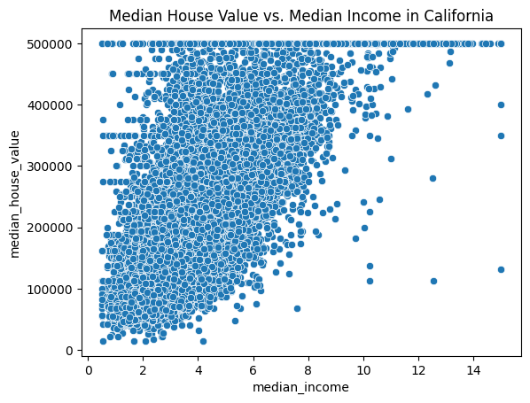

```python
import seaborn as sns
sns.scatterplot(x="median_income", y="median_house_value", data=housing).set(title='Median House Value vs. Median Income in California')
```

**2. Median House Value vs. Population**

The scatter plot illustrates the relationship between population and median house value in California. Generally, there doesn't seem to be a clear correlation between population and median house value. There is a slight decline in median house value as population increases. This suggests a negative correlation between population and housing prices, meaning that regions with higher populations tend to have slightly lower median house values. However, the relationship is not very strong.

```
[Text(0.5, 1.0, 'Median House Value vs. Population in California')]
```

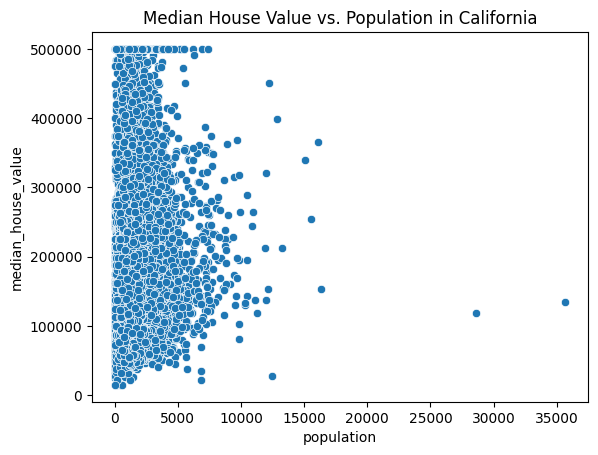

```python
sns.scatterplot(x="population", y="median_house_value", data=housing).set(title='Median House Value vs. Population in California')
```

**3. Median House Value vs. Number of Househols**

The scatter plot showcases the relationship between the number of households and the median house value in California. It indicates a minor increase in median house value as the number of households increases. This suggests a positive correlation between the number of households and housing prices, implying that regions with a higher number of households tend to have slightly higher median house values.

```
[Text(0.5, 1.0, 'Median House Value vs. Number of Households in California')]
```

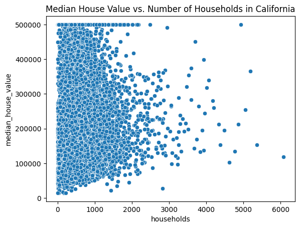

```python
sns.scatterplot(x="households", y="median_house_value", data=housing).set(title='Median House Value vs. Number of Households in California')
```

### Q4 linear regressions (fitting)

**Model-1. Median house Value vs. Median Income**

```python
from sklearn import linear_model

model1 = linear_model.LinearRegression()
model1.fit(X=housing[["median_income"]], y=housing[["median_house_value"]])
```

```
LinearRegression()
```

**Model-2. Median House Value vs. Population**

```python
model2 = linear_model.LinearRegression()
model2.fit(X=housing[["population"]], y=housing[["median_house_value"]])
```

```
LinearRegression()
```

**Model-3. Median House Value vs. Households**

```python
model3 = linear_model.LinearRegression()
model3.fit(X=housing[["households"]], y=housing[["median_house_value"]])
```

```
LinearRegression()
```

### Q5. Summarize in a table, for each of the three models:

i. intercept and slope

ii. Mean Squared Error - the loss : The average of the square of the errors of all the data-points in the given dataset

iii. Mean Absolute Error : The average of absolute errors of all the data-points in the given dataset

**Model-1. Median House Value vs. Median Income**

```python
from sklearn.metrics import mean_squared_error, mean_absolute_error
print(f"Intercept: {model1.intercept_}")
print(f"Coefficients: {model1.coef_}")
print(f"Mean squared error: {mean_squared_error(housing[['median_house_value']], model1.predict(housing[['median_income']]))}")
print(f"Mean absolute error: {mean_absolute_error(housing[['median_house_value']], model1.predict(housing[['median_income']]))}")
```

```
Intercept: [45085.57670327]
Coefficients: [[41793.8492019]]
Mean squared error: 7011311502.929527
Mean absolute error: 62625.9337911434
```

**Model-2. Median House Value vs. Population**

```python
print(f"Intercept: {model2.intercept_}")
print(f"Coefficients: {model2.coef_}")
print(f"Mean squared error: {mean_squared_error(housing[['median_house_value']], model2.predict(housing[['population']]))}")
print(f"Mean absolute error: {mean_absolute_error(housing[['median_house_value']], model2.predict(housing[['population']]))}")
```

```
Intercept: [210436.26207627]
Coefficients: [[-2.51175277]]
Mean squared error: 13307412412.389355
Mean absolute error: 91153.82009473183
```

**Model-3. Median House Value vs. Households**

```python
print(f"Intercept: {model3.intercept_}")
print(f"Coefficients: {model3.coef_}")
print(f"Mean squared error: {mean_squared_error(housing[['median_house_value']], model3.predict(housing[['households']]))}")
print(f"Mean absolute error: {mean_absolute_error(housing[['median_house_value']], model3.predict(housing[['households']]))}")
```

```
Intercept: [196928.57716233]
Coefficients: [[19.87277516]]
Mean squared error: 13257776904.728533
Mean absolute error: 90802.74324318448
```

|  | Median House Value vs. Median Income | Median House Value vs. Population | Median House Value vs. Households |
| --- | --- | --- | --- |
| Intercept | 45085.57670327 | 210436.26207627 | 196928.57716233 |
| Coefficient(slope) | 41793.8492019 | -2.51175277 | 19.87277516 |
| Mean squared error | 7011311502.929527 | 13307412412.389355 | 13257776904.728533 |
| Mean absolute error | 62625.9337911434 | 91153.82009473183 | 90802.74324318448 |

### Q6. Plot the resulting line on top of the scatter data for each of the three models

**Model-1. Median House Value vs. Median Income**

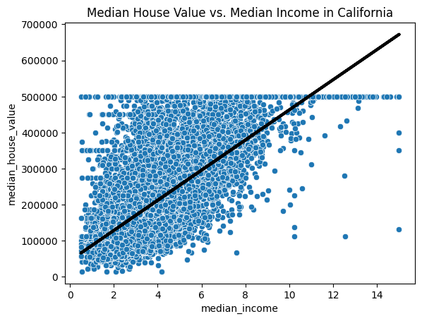

```python
import matplotlib.pyplot as plt
sns.scatterplot(x="median_income", y="median_house_value", data=housing).set(title='Median House Value vs. Median Income in California')
plt.plot(housing[["median_income"]], model1.predict(housing[["median_income"]]), color="black", linewidth=3)
plt.show()
```

**Model-2. Median House Value vs. Population**

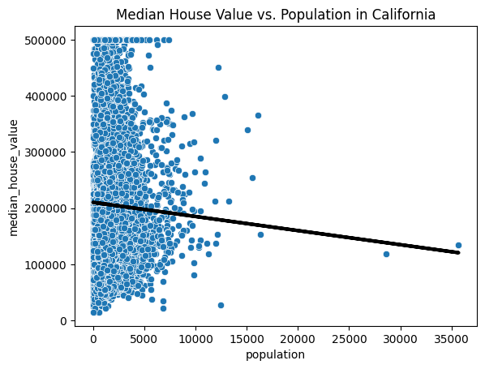

```python
sns.scatterplot(x="population", y="median_house_value", data=housing).set(title='Median House Value vs. Population in California')
plt.plot(housing[["population"]], model2.predict(housing[["population"]]), color="black", linewidth=3)
plt.show()
```

**Model-3. Median House Value vs. Households**

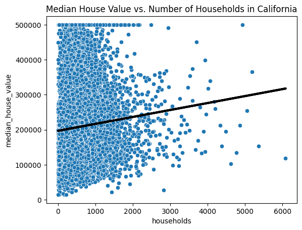

```python
sns.scatterplot(x="households", y="median_house_value", data=housing).set(title='Median House Value vs. Number of Households in California')
plt.plot(housing[["households"]], model3.predict(housing[["households"]]), color="black", linewidth=3)
plt.show()
```